# 12주차

Hosub Park

2016년 6월 6일

## <12주차>

### 1. Using the sat dataset, fit a model with the total SAT score as the response and expend, salary, ratio and takers as predictors. Perform regression diagnostics on this model to answer the following questions. Display any plots that are relevent. Do not provide any plots about which you have nothing to say.

```r
library(faraway)
data(sat)

mdl <- lm(total~expend+salary+ratio+takers, data=sat)
```

#### (a) Check the constant variance assumption for the errors.

```r
library(car)
ncvTest(mdl)
```

```
## Non-constant Variance Score Test
## Variance formula: ~ fitted.values
## Chisquare = 0.6972119    Df = 1     p = 0.4037221
```

p값이 0.4037으로 등분산이라는 귀무가설을 기각하지 못함.

#### (b) Check the normality assumption.

```r
shapiro.test(mdl$residuals)
```

```
##
##  Shapiro-Wilk normality test
##
## data:  mdl$residuals
## W = 0.97691, p-value = 0.4304
```

p값이 0.4304으로 귀무가설을 기각하지 못하므로 정규성을 띤다.

#### (c) Check for large leverage points.

```r
mdl_inf <- influence(mdl)
```

2p/n보다 큰값을 가진 hat을 찾는다.

```r
mdl_inf$hat[which(mdl_inf$hat > 2*5/50)]
```

```
##  California Connecticut  New Jersey        Utah
##   0.2821179   0.2254519   0.2220978   0.2921128
```

4개 발견됨

#### (d) Check for outliers.

```r
outlierTest(mdl)
```

```
##
## No Studentized residuals with Bonferonni p < 0.05
## Largest |rstudent|:
##                rstudent unadjusted p-value Bonferonni p
## West Virginia -3.124428          0.0031496      0.15748
```

Bonferonni p값이 0.05미만인 값은 없으므로 ourlier는 없다.

#### (e) Check for influential points.

```r
max(cooks.distance(mdl))
```

```
## [1] 0.4715287
```

cook distance의 최대값은 0.47으로 강력한 influential point는 없다.

#### (f) Check the structure of the relationship between the predictors and the response.

expend

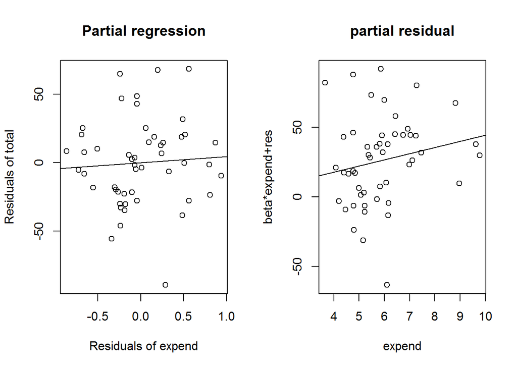

```r
par(mfrow=c(1,2))
d <- lm(total~.-expend, data=sat[,-c(5:6)])$residuals
m <- lm(expend~.-total, data=sat[,-c(5:6)])$residuals
plot(m,d, xlab="Residuals of expend", ylab="Residuals of total", main="Partial regression")
abline(0, mdl$coefficients[2])

plot(sat$expend, mdl$residuals+mdl$coefficients[2]*sat$expend, xlab="expend", ylab="beta*expend+res", main="partial residual")
abline(0,mdl$coefficients[2])
```

```r
par(mfrow=c(1,1))
```

salary

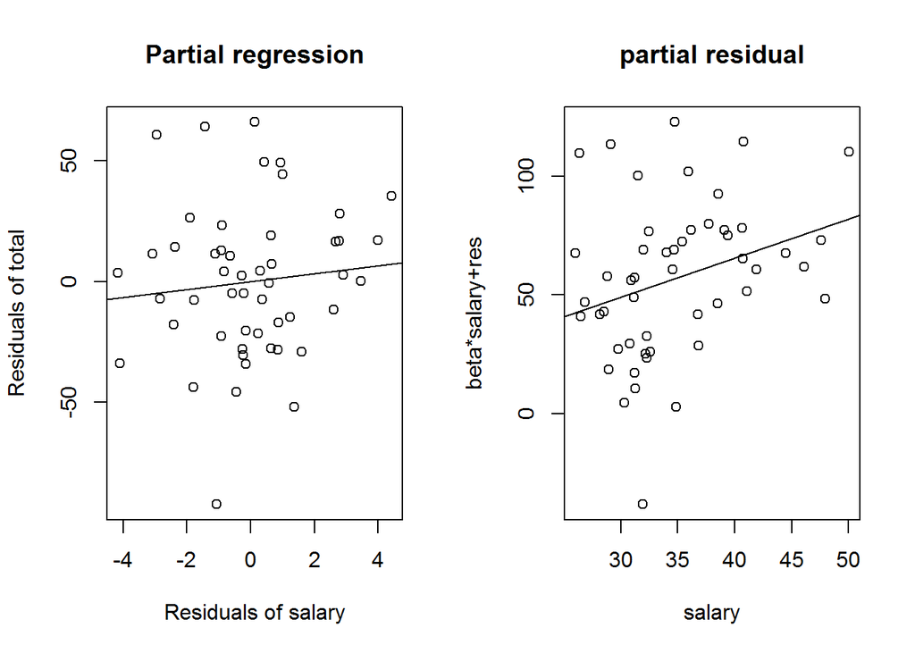

```r
par(mfrow=c(1,2))
d <- lm(total~.-salary, data=sat[,-c(5:6)])$residuals
m <- lm(salary~.-total, data=sat[,-c(5:6)])$residuals
plot(m,d, xlab="Residuals of salary", ylab="Residuals of total", main="Partial regression")
abline(0, mdl$coefficients[3])

plot(sat$salary, mdl$residuals+mdl$coefficients[3]*sat$salary, xlab="salary", ylab="beta*salary+res", main="partial residual")
abline(0,mdl$coefficients[3])
```

```r
par(mfrow=c(1,1))
```

ratio

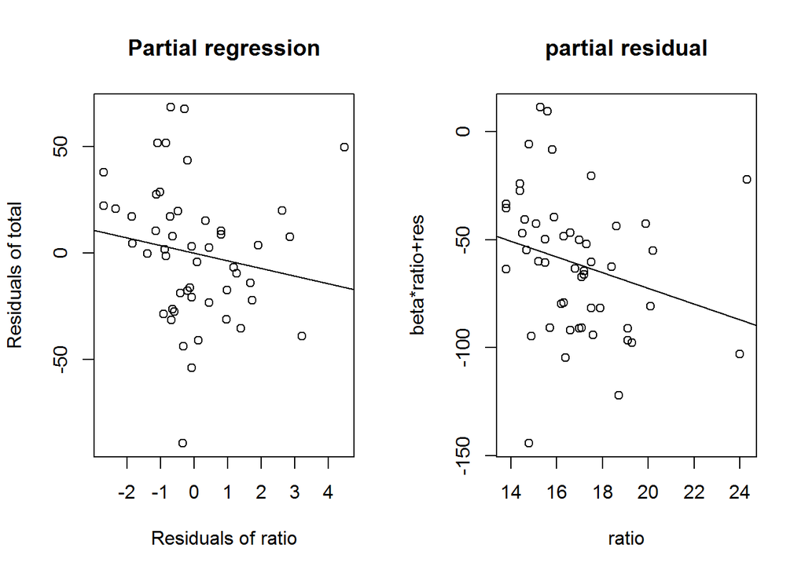

```r
par(mfrow=c(1,2))
d <- lm(total~.-ratio, data=sat[,-c(5:6)])$residuals
m <- lm(ratio~.-total, data=sat[,-c(5:6)])$residuals
plot(m,d, xlab="Residuals of ratio", ylab="Residuals of total", main="Partial regression")
abline(0, mdl$coefficients[4])

plot(sat$ratio, mdl$residuals+mdl$coefficients[4]*sat$ratio, xlab="ratio", ylab="beta*ratio+res", main="partial residual")
abline(0,mdl$coefficients[4])
```

```r
par(mfrow=c(1,1))
```

takers

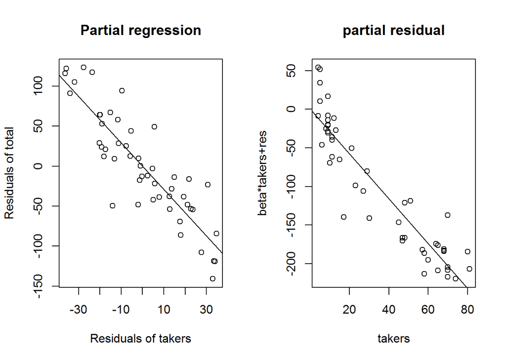

```r
par(mfrow=c(1,2))
d <- lm(total~.-takers, data=sat[,-c(5:6)])$residuals
m <- lm(takers~.-total, data=sat[,-c(5:6)])$residuals
plot(m,d, xlab="Residuals of takers", ylab="Residuals of total", main="Partial regression")
abline(0, mdl$coefficients[5])

plot(sat$takers, mdl$residuals+mdl$coefficients[5]*sat$takers, xlab="takers", ylab="beta*takers+res", main="partial residual")
abline(0,mdl$coefficients[5])
```

```r
par(mfrow=c(1,1))
```

### 2. For the swiss data, fit a model with Fertility as the response and the other variables as predictors. Answer the questions posed in the first question.

```r
data("swiss")
mdl <- lm(Fertility~., data=swiss)
```

#### (a) Check the constant variance assumption for the errors.

```r
ncvTest(mdl)
```

```
## Non-constant Variance Score Test
## Variance formula: ~ fitted.values
## Chisquare = 0.3077424    Df = 1     p = 0.5790689
```

p값이 0.5790으로 귀무가설을 기각할수 없으므로 등분산임.

#### (b) Check the normality assumption.

```r
shapiro.test(mdl$residuals)
```

```
##
##  Shapiro-Wilk normality test
##
## data:  mdl$residuals
## W = 0.98892, p-value = 0.9318
```

p값이 0.9318으로 귀무가설을 기각할수 없으므로 정규성을 가짐.

#### (c) Check for large leverage points.

```r
mdl_inf <- influence(mdl)
```

2p/n보다 큰값을 가진 hat을 찾는다.

```r
mdl_inf$hat[which(mdl_inf$hat > 2*6/47)]
```

```
##    La Vallee V. De Geneve
##    0.3512078    0.4558363
```

2개 발견.

#### (d) Check for outliers.

```r
outlierTest(mdl)
```

```
##
## No Studentized residuals with Bonferonni p < 0.05
## Largest |rstudent|:
##        rstudent unadjusted p-value Bonferonni p
## Sierre 2.445227           0.018974      0.89177
```

Bonferonni p값이 0.05미만인 값은 없으므로 ourlier는 없다.

#### (e) Check for influential points.

```r
max(cooks.distance(mdl))
```

```
## [1] 0.2077343
```

cook distance의 최대값은 0.21으로 강력한 influential point는 없다.

#### (f) Check the structure of the relationship between the predictors and the response.

Agriculture

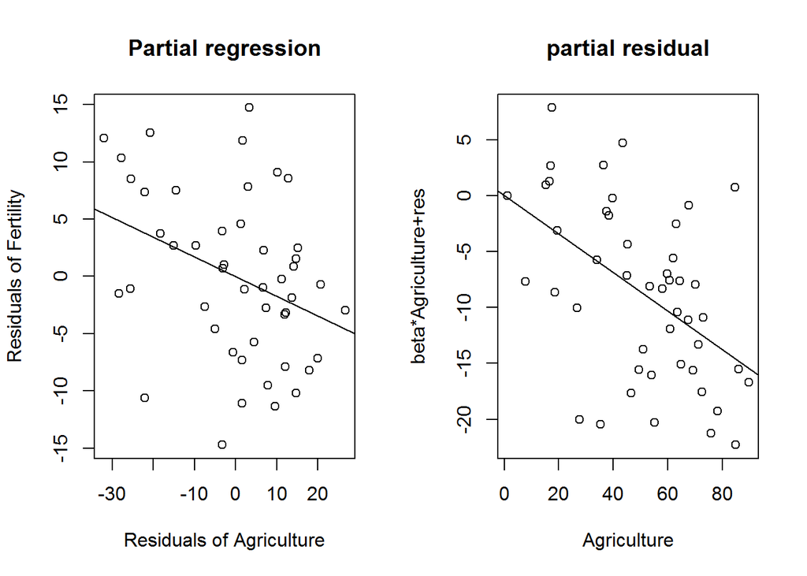

```r
par(mfrow=c(1,2))
d <- lm(Fertility~.-Agriculture, data=swiss)$residuals
m <- lm(Agriculture~.-Fertility, data=swiss)$residuals
plot(m,d, xlab="Residuals of Agriculture", ylab="Residuals of Fertility", main="Partial regression")
abline(0, mdl$coefficients[2])

plot(swiss$Agriculture, mdl$residuals+mdl$coefficients[2]*swiss$Agriculture, xlab="Agriculture", ylab="beta*Agriculture+res", main="partial residual")
abline(0,mdl$coefficients[2])
```

```r
par(mfrow=c(1,1))
```

Examination

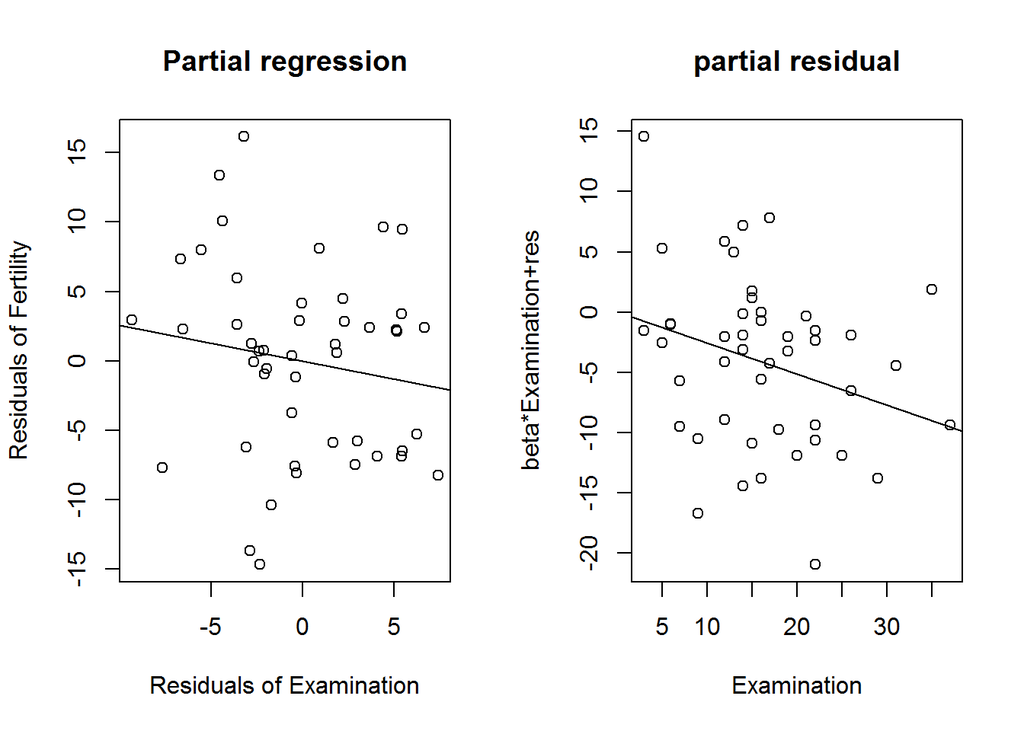

```r
par(mfrow=c(1,2))
d <- lm(Fertility~.-Examination, data=swiss)$residuals
m <- lm(Examination~.-Fertility, data=swiss)$residuals
plot(m,d, xlab="Residuals of Examination", ylab="Residuals of Fertility", main="Partial regression")
abline(0, mdl$coefficients[3])

plot(swiss$Examination, mdl$residuals+mdl$coefficients[3]*swiss$Examination, xlab="Examination", ylab="beta*Examination+res", main="partial residual")
abline(0,mdl$coefficients[3])
```

```r
par(mfrow=c(1,1))
```

Education

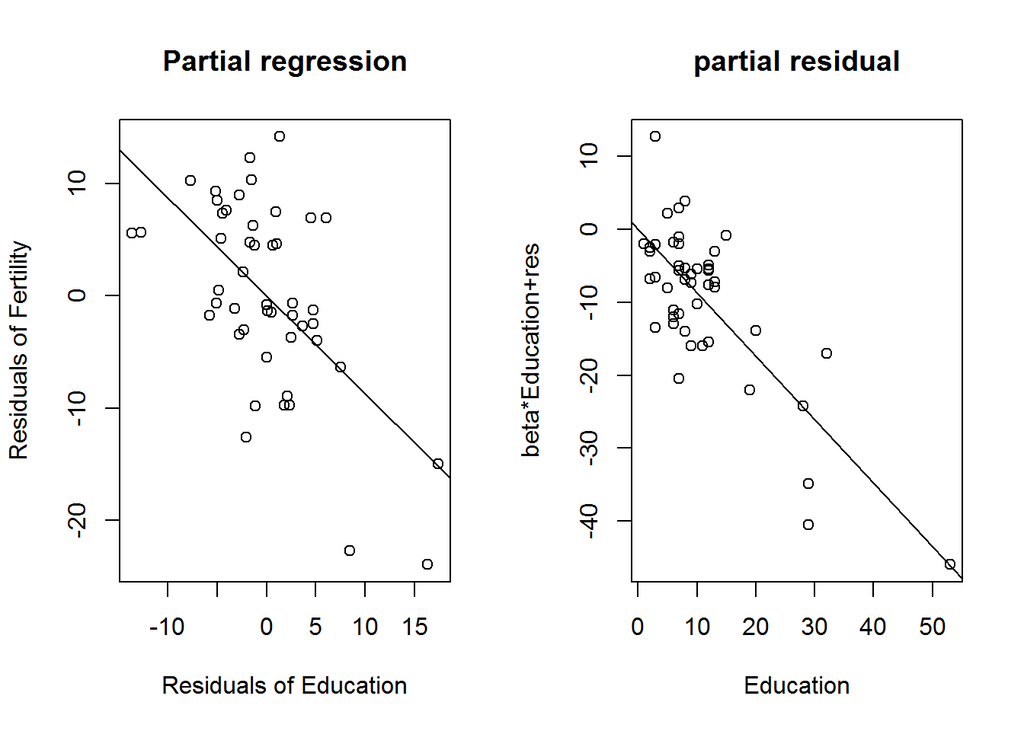

```r
par(mfrow=c(1,2))
d <- lm(Fertility~.-Education, data=swiss)$residuals
m <- lm(Education~.-Fertility, data=swiss)$residuals
plot(m,d, xlab="Residuals of Education", ylab="Residuals of Fertility", main="Partial regression")
abline(0, mdl$coefficients[4])

plot(swiss$Education, mdl$residuals+mdl$coefficients[4]*swiss$Education, xlab="Education", ylab="beta*Education+res", main="partial residual")
abline(0,mdl$coefficients[4])
```

```r
par(mfrow=c(1,1))
```

Catholic

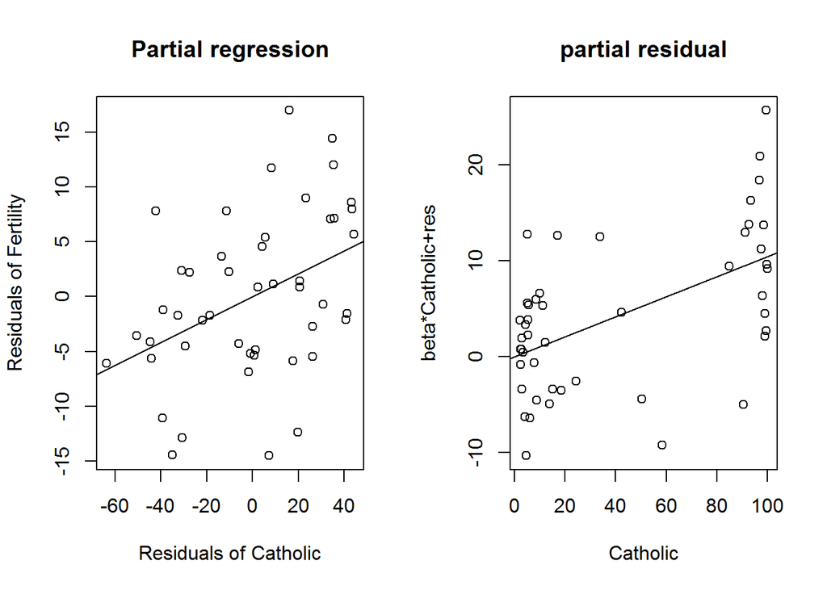

```r
par(mfrow=c(1,2))
d <- lm(Fertility~.-Catholic, data=swiss)$residuals
m <- lm(Catholic~.-Fertility, data=swiss)$residuals
plot(m,d, xlab="Residuals of Catholic", ylab="Residuals of Fertility", main="Partial regression")
abline(0, mdl$coefficients[5])

plot(swiss$Catholic, mdl$residuals+mdl$coefficients[5]*swiss$Catholic, xlab="Catholic", ylab="beta*Catholic+res", main="partial residual")
abline(0,mdl$coefficients[5])
```

```r
par(mfrow=c(1,1))
```

Infant.Mortality

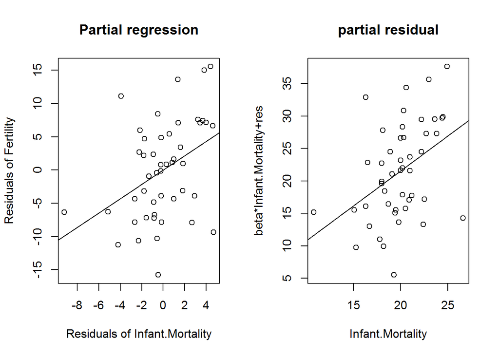

```r
par(mfrow=c(1,2))
d <- lm(Fertility~.-Infant.Mortality, data=swiss)$residuals
m <- lm(Infant.Mortality~.-Fertility, data=swiss)$residuals
plot(m,d, xlab="Residuals of Infant.Mortality", ylab="Residuals of Fertility", main="Partial regression")
abline(0, mdl$coefficients[6])

plot(swiss$Infant.Mortality, mdl$residuals+mdl$coefficients[6]*swiss$Infant.Mortality, xlab="Infant.Mortality", ylab="beta*Infant.Mortality+res", main="partial residual")
abline(0,mdl$coefficients[6])
```

```r
par(mfrow=c(1,1))
```